# Average Marginal Effects for Multinomial Logistic Regression in R

2020-01-05

Multinomial logistic regression is a commonly used statistical technique when you have an outcome variable with multiple, unordered, categories. As per Richard McElreath’ [Statistical Rethinking](https://xcelab.net/rm/statistical-rethinking/), parameter estimates from multinomial models can be really hard to understand. the values of the covariates only relate to comparisons with the reference class, and as with any logistic model, have to be interpreted in the context of the other independent variables in the model.

The `{margins}` package does a great job of calculating marginal effects out of the box, but one slight snag is that it does so only for one level of the dependent variable at a time when the outcome is multinomial. It’s easy enough though to loop through each level of the dependent variable using the `map` function from `{purrr}` to calculate AMEs for all levels of a multinomial outcome variable.

*We can show this with a worked example.*

First load the packages we’ll need.

```r
library(tidyverse)
library(nnet)
library(margins)
library(haven)
```

Then we can load in some data. UCLA has an excellent [worked example of multinomial logistic regression](https://stats.idre.ucla.edu/r/dae/multinomial-logistic-regression/) (amongst other things), so we’ll use their dataset.

```r
# I'm using data from this worked example
# https://stats.idre.ucla.edu/r/dae/multinomial-logistic-regression/

df <- read_dta("https://stats.idre.ucla.edu/stat/data/hsbdemo.dta")
```

UCLA describe the dataset as:

> Entering high school students make program choices among general program, vocational program and academic program. Their choice might be modeled using their writing score and their social economic status.

It has 200 observations and a bunch of variables.

```r
glimpse(df)
```

```
## Observations: 200
## Variables: 13
## $ id      <dbl> 45, 108, 15, 67, 153, 51, 164, 133, 2, 53, 1, 128, 16, 1…
## $ female  <dbl+lbl> 1, 0, 0, 0, 0, 1, 0, 0, 1, 0, 1, 0, 0, 1, 1, 0, 1, 1…
## $ ses     <dbl+lbl> 1, 2, 3, 1, 2, 3, 2, 2, 2, 2, 1, 3, 1, 2, 1, 1, 1, 2…
## $ schtyp  <dbl+lbl> 1, 1, 1, 1, 1, 1, 1, 1, 1, 1, 1, 1, 1, 1, 1, 1, 1, 1…
## $ prog    <dbl+lbl> 3, 1, 3, 3, 3, 1, 3, 3, 3, 3, 3, 2, 3, 3, 3, 1, 1, 3…
## $ read    <dbl> 34, 34, 39, 37, 39, 42, 31, 50, 39, 34, 34, 39, 47, 36, …
## $ write   <dbl> 35, 33, 39, 37, 31, 36, 36, 31, 41, 37, 44, 33, 31, 44, …
## $ math    <dbl> 41, 41, 44, 42, 40, 42, 46, 40, 33, 46, 40, 38, 44, 37, …
## $ science <dbl> 29, 36, 26, 33, 39, 31, 39, 34, 42, 39, 39, 47, 36, 42, …
## $ socst   <dbl> 26, 36, 42, 32, 51, 39, 46, 31, 41, 31, 41, 41, 36, 41, …
## $ honors  <dbl+lbl> 0, 0, 0, 0, 0, 0, 0, 0, 0, 0, 0, 0, 0, 0, 0, 0, 0, 0…
## $ awards  <dbl> 0, 0, 0, 0, 0, 0, 0, 0, 0, 0, 0, 0, 0, 0, 0, 0, 0, 0, 0,…
## $ cid     <dbl> 1, 1, 1, 1, 1, 1, 1, 1, 1, 1, 1, 2, 2, 2, 2, 2, 2, 2, 2,…
```

For sake of simplicity, lets remove some of the variables in the dataset and recode all the independent variables so they’re binary.

```r
# data wrangling ----------------------------------------------------------

# remove some variables for sake of simplicity, and
# recode everything to binary variables

df <-
  df %>%
  select(id:prog, honors) %>%
  mutate_at(vars(female:honors), as.numeric) %>%
  mutate(ses = if_else(ses > 1, 2, 1)) %>%
  mutate_at(vars(female:honors), as.factor)
```

Now let’s fit a model using `{nnet}`. This isn’t how you’d want to proceed if trying to understand this dataset for real (for example, comparing model fit with a null model etc.)

```r
# fit the model -----------------------------------------------------------

model_data <- df

mod_nnet <-
  multinom(data = model_data,
      prog ~ 1 # outcome variable with an intercept
      + female # one dependent variable
      + ses
      + schtyp
      + honors
      )
```

Now we have our saved model in the object `mod_nnet`. To calculate the AMEs we can use the `marginal_effects` function from `{margins}`. This is a stripped down version of the packages’ main function `margins`, which does not try to calculate standard errors for the marginal effects (these are not defined for `{nnet}` models. We’ll talk about how to calculate bootstrap standard errors for these AMEs in another post). To get the desired structure for the results we create a user defined function which lets us explicitly specify the category of the dependent variable we want to calculate AMEs for, and `marginal_effects` will calculate AMEs for all the covariates.

```r
marg <- function(classes){

  margins::marginal_effects(mod_nnet, category = classes)

}
```

As an aside, this function references the model object `mod_nnet` which exists in the global environment. This function will only work because we just created this object a second ago, and because of R’s [scoping rules](https://adv-r.hadley.nz/functions.html#lexical-scoping) R will look for objects within the global environment if it doesn’t find the object within the function environment. This allows us to fit the model once and then reference it for every iteration of the marginal effects.

We then extract the levels of the dependent variable from the dataset (there’s probably a neater way of doing this, but hey this works).

```r
classes <-
  model_data %>%
  count(prog) %>%
  pull(prog)
```

Now we can finally apply our wrapper function `marg` to each level of our dependent variable. First we make a dataframe of our factor levels sttored in a variable `.category` and then use the `map` function to pass each of these factors levels to `marg`. By wrapping this whole process in `mutate` will give us a [nested dataframe](https://r4ds.had.co.nz/many-models.html) with three 200 x 4 dataframes: one set of marginal effects for each observation (there were 200 in the original dataset) for each of our four covariates, for each of the three levels of the dependent variable.

```r
classes <-
  tibble(
  .category = classes
  ) %>%
  mutate(marginals = map(.category, marg))
```

Now we can use the standard tools for working on dataframes to just calculate the average marginal effect for each each variable and each category. First we `unnest` the dataframe, then use `group_by` and `summarise_all` to calculate the AME for each level of the dependent variable for each covariate.

```r
# overall AME
ame <-
  classes %>%
  unnest(col = c(marginals)) %>%
  group_by(.category) %>%
  summarise_all(., mean)
```

With a last bit of wrangling to convert the dataset into a longer format that `ggplot2` will like, we can the plot our results:

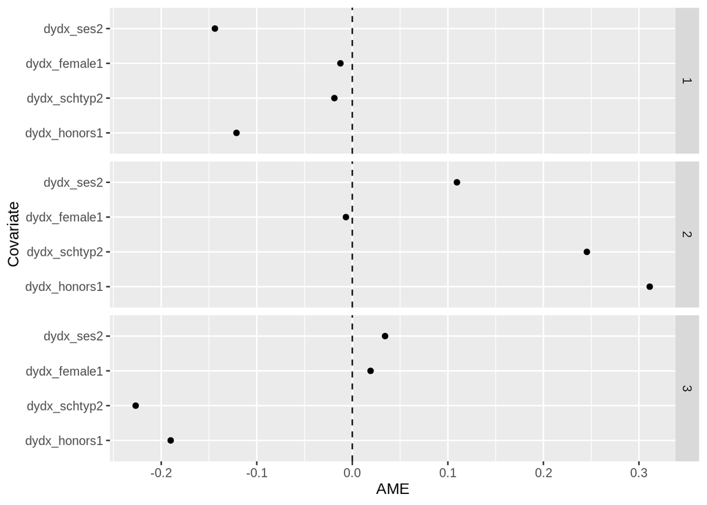

```r
ame %>%
  gather(iv, ame, 2:5) %>%
  ggplot(aes(
  y = fct_reorder(iv, ame),
  x = ame
)) +
  geom_vline(xintercept = 0, linetype = "dashed") +
  geom_point(
  ) +
  facet_wrap(vars(.category),
             ncol = 1,
             strip.position = "right"
  ) +
  labs(y = "Covariate",
       x = "AME")
```

These results are on the probability scale, so we can say that being in category 2 of ses rather than category 1 of ses decreases the probability of being in category 1 by around 15 percentage points for the people in this dataset. The inverse of this is that having ses category 2 increases the probability of being in category 2 by just over 10 percentage points, and catgory 3 by around 4 percentage points.

[^1]: The process works *slightly differently* for continuous variables though.